# Detection mode project: Tables and figures for publication

Author

Martina Brayley

Published

July 29, 2024

# 1 Table and figure structure:

**Main tables**

Table 1 - general descriptives (population characteristics)

Table 2 - Risk factor descriptives by detection mode with logistic regression results (unadjusted for TC) - all cases

**Main figures**

Figure 1 - comprised figure of plots describing mamographic density in relation to risk factors (detail in ST 2)

**Supplementary material**

(ST = Supplementary Table)

ST 2 - risk factor descriptives by density (complementing figure 1)

ST 4 - TC descriptives by detection mode with logistic regression results

ST 5 - Risk factor analysis adjusted for tumour characteristics (sensitivity analysis) - on subset of cases with TC

# 2 Main tables

## 2.1 Table 1 - general participant descriptives

stage coding - DCIS coded as stage 0 - should we keep it that way or code them as unknown? or DCIS?

time from recruitement to diagnosis categorical or continuous?

| **Characteristic** | **N = 1,940**<sup>1</sup> |
| --- | --- |
| Age at diagnosis | 61.39 (6.55) |
| Age at recruitment | 54.67 (7.00) |
| Time from recruitment to diagnosis |  |
| <3 years | 371 (19) |
| 3 to 5 years | 449 (23) |
| 6 to 8 years | 507 (26) |
| 9 to 11 years | 469 (24) |
| >12 years | 144 (7.4) |
| Time from recruitment to diagnosis | 6.72 (3.64) |
| Invasive status |  |
| DCIS | 308 (16) |
| Invasive | 1,632 (84) |
| Grade |  |
| 1 | 338 (21) |
| 2 | 812 (51) |
| 3 | 451 (28) |
| Unknown | 339 |
| Stage |  |
| 0 | 308 (18) |
| 1 | 787 (47) |
| 2 | 487 (29) |
| 3 | 80 (4.7) |
| 4 | 27 (1.6) |
| Unknown | 251 |
| Morphology type |  |
| Ductal | 1,247 (76) |
| Lobular | 214 (13) |
| Mixed: ductal and other | 68 (4.2) |
| Other | 103 (6.3) |
| Unknown | 308 |
| Positive nodes |  |
| Negative | 905 (68) |
| Positive | 428 (32) |
| Unknown | 607 |
| Tumour size |  |
| <21 | 992 (70) |
| 21-50 | 387 (27) |
| 50+ | 46 (3.2) |
| Unknown | 515 |
| ER status |  |
| Positive | 1,316 (85) |
| Negative | 224 (15) |
| Unknown | 400 |
| PR status |  |
| Positive | 658 (67) |
| Negative | 329 (33) |
| Unknown | 953 |
| HER2 status |  |
| Positive | 194 (13) |
| Negative | 1,249 (87) |
| Unknown | 497 |

<sup>1</sup> Mean (SD); n (%)

## 2.2 Table 2 - Main analysis

The main analysis is a logistic regression with multiple exposures (risk factors).

This table shows risk factor level descriptives and their associations with the mode of detection (logistic regression) adjusted for all other risk factors, age at diagnosis and time from entry to BC diagnosis.

Model 2 is the final selected model (Default model) to present in the analysis. Model 2 is adjusted for all co-exposures + age at diagnosis and time from entry to BC diagnosis. Model 1 was only adjusted for co-exposures, e.i. all exposures in the model.

Because model 2 was selected as the default model, it is also used on the subanalyses with TC and MD as the comparison against adjusted models for TC and MD.

| **Characteristic** | **I**, N = 755<sup>1</sup> | **SD**, N = 1,185<sup>1</sup> | **OR**<sup>2</sup> | **95% CI**<sup>2</sup> | **p-value** |
| --- | --- | --- | --- | --- | --- |
| Menopause |  |  |  |  | 0.4 |
| Premenopausal | 242 (32) | 355 (30) | — | — |  |
| Postmenopausal | 513 (68) | 830 (70) | 0.84 | 0.55, 1.27 |  |
| N of parous pregnancies |  |  |  |  | 0.7 |
| 0 | 97 (13) | 161 (14) | — | — |  |
| 1 | 86 (11) | 125 (11) | 1.52 | 0.80, 2.88 |  |
| 2 | 408 (54) | 630 (53) | 1.38 | 0.78, 2.44 |  |
| 3+ | 164 (22) | 269 (23) | 1.33 | 0.74, 2.37 |  |
| Age at menarche |  |  |  |  | 0.081 |
| <12 | 153 (22) | 260 (24) | — | — |  |
| 12-13 | 369 (53) | 523 (49) | 1.18 | 0.92, 1.53 |  |
| 14+ | 169 (24) | 286 (27) | 0.91 | 0.67, 1.22 |  |
| Unknown | 64 | 116 |  |  |  |
| Oral contraceptives status |  |  |  |  | 0.5 |
| Never | 95 (13) | 182 (15) | — | — |  |
| Former | 639 (85) | 967 (82) | 1.22 | 0.89, 1.66 |  |
| Current | 20 (2.7) | 34 (2.9) | 1.17 | 0.57, 2.34 |  |
| Unknown | 1 | 2 |  |  |  |
| Benign breast disease |  |  |  |  | <0.001 |
| No | 467 (62) | 831 (70) | — | — |  |
| Yes | 288 (38) | 354 (30) | 1.47 | 1.19, 1.82 |  |
| Family history of BC |  |  |  |  | 0.020 |
| No | 564 (75) | 931 (79) | — | — |  |
| Yes | 191 (25) | 254 (21) | 1.32 | 1.05, 1.67 |  |
| Alcohol units |  |  |  |  | 0.3 |
| 0 | 149 (20) | 258 (22) | — | — |  |
| 1-9 | 200 (26) | 317 (27) | 1.07 | 0.79, 1.44 |  |
| 10-19 | 208 (28) | 290 (24) | 1.28 | 0.95, 1.73 |  |
| 20-29 | 126 (17) | 190 (16) | 1.06 | 0.75, 1.49 |  |
| 30+ | 72 (9.5) | 130 (11) | 0.89 | 0.60, 1.32 |  |
| Smoking status |  |  |  |  | 0.6 |
| Never | 453 (60) | 709 (60) | — | — |  |
| Former | 261 (35) | 392 (33) | 1.01 | 0.81, 1.27 |  |
| Current | 41 (5.4) | 82 (6.9) | 0.80 | 0.52, 1.22 |  |
| Unknown | 0 | 2 |  |  |  |
| BMI |  |  |  |  | 0.006 |
| <18.5 | 8 (1.1) | 3 (0.3) | 3.22 | 0.82, 15.8 |  |
| 18.5-25 | 421 (56) | 550 (47) | — | — |  |
| 25-30 | 203 (27) | 405 (35) | 0.71 | 0.57, 0.90 |  |
| 30+ | 116 (16) | 213 (18) | 0.76 | 0.57, 1.02 |  |
| Unknown | 7 | 14 |  |  |  |
| Physical Activity (WHO cat) |  |  |  |  | 0.4 |
| <9 | 153 (20) | 271 (23) | — | — |  |
| 9-18 | 145 (19) | 246 (21) | 0.89 | 0.65, 1.22 |  |
| 18+ | 451 (60) | 660 (56) | 1.07 | 0.83, 1.38 |  |
| Unknown | 6 | 8 |  |  |  |
| Age at menopause |  |  |  |  | 0.026 |
| <50 | 116 (15) | 185 (16) | — | — |  |
| 50-54 | 332 (44) | 570 (48) | 0.87 | 0.65, 1.18 |  |
| 55+ | 64 (8.5) | 71 (6.0) | 1.52 | 0.96, 2.41 |  |
| Pre-menopausal | 242 (32) | 355 (30) |  |  |  |
| Unknown | 1 | 4 |  |  |  |
| HRT status |  |  |  |  | 0.023 |
| Never | 192 (26) | 354 (30) | — | — |  |
| Former | 161 (21) | 281 (24) | 1.07 | 0.80, 1.45 |  |
| Current | 157 (21) | 192 (16) | 1.51 | 1.11, 2.06 |  |
| Pre-menopausal | 242 (32) | 353 (30) |  |  |  |
| Unknown | 3 | 5 |  |  |  |
| Age at first birth |  |  |  |  | 0.5 |
| <20 | 35 (4.6) | 45 (3.8) | — | — |  |
| 20-24 | 197 (26) | 308 (26) | 0.80 | 0.48, 1.35 |  |
| 25-29 | 256 (34) | 421 (36) | 0.68 | 0.41, 1.14 |  |
| 30-34 | 122 (16) | 174 (15) | 0.81 | 0.47, 1.42 |  |
| 35+ | 46 (6.1) | 71 (6.0) | 0.69 | 0.36, 1.33 |  |
| Non-parous | 97 (13) | 161 (14) |  |  |  |
| Unknown | 2 | 5 |  |  |  |

<sup>1</sup> n (%)  
<sup>2</sup> OR = Odds Ratio, CI = Confidence Interval

# 3 Main figures

## 3.1 Figure 1 - descriptives of risk factors with MD

This section will include more figures - structure to be decided

### 3.1.1 Reproductive, lifestyle and other risk factors

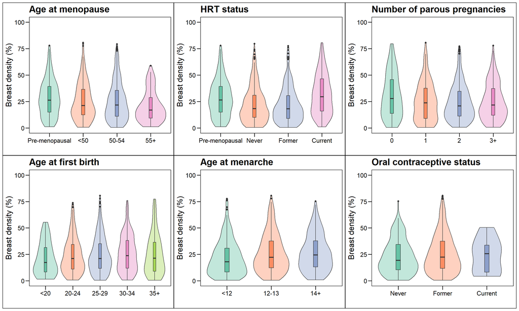

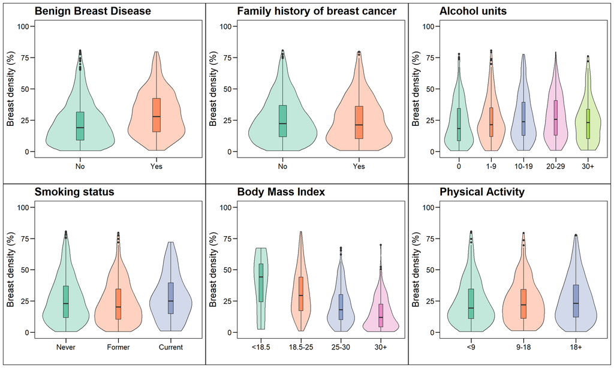

### 3.1.2 Tumour characteristics

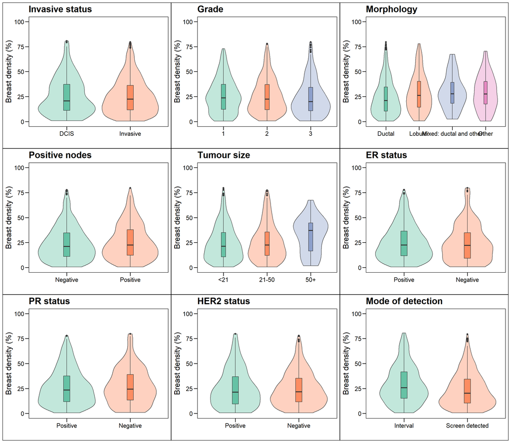

## 3.2 Figure 2 - adjusting for MD

**Decision needed**

Decided to use quartiles on 15/07/2024

### 3.2.1 Categorical MD (quartiles)

| term | estimate | std.error | statistic | p.value | conf.low | conf.high |
| --- | --- | --- | --- | --- | --- | --- |
| (Intercept) | -1.16 | 1.02 | -1.13 | 0.258 | -3.17 | 0.843 |
| d_R1menopause_lab3Postmenopausal | -0.34 | 0.289 | -1.17 | 0.24 | -0.91 | 0.225 |
| d_age_meno_tr_lab50-54 | -0.115 | 0.193 | -0.594 | 0.552 | -0.49 | 0.268 |
| d_age_meno_tr_lab55+ | 0.587 | 0.284 | 2.07 | 0.0389 | 0.0299 | 1.15 |
| d_R1hrt_tr_labFormer | 0.078 | 0.194 | 0.402 | 0.688 | -0.303 | 0.458 |
| d_R1hrt_tr_labCurrent | 0.676 | 0.196 | 3.45 | 0.000564 | 0.293 | 1.06 |
| d_parity_lab1 | 0.118 | 0.445 | 0.266 | 0.79 | -0.766 | 0.983 |
| d_parity_lab2 | 0.154 | 0.398 | 0.386 | 0.7 | -0.641 | 0.926 |
| d_parity_lab3+ | 0.189 | 0.405 | 0.466 | 0.642 | -0.62 | 0.975 |
| d_agebirth1_tr_lab20-24 | -0.16 | 0.363 | -0.442 | 0.659 | -0.86 | 0.57 |
| d_agebirth1_tr_lab25-29 | -0.178 | 0.358 | -0.496 | 0.62 | -0.869 | 0.545 |
| d_agebirth1_tr_lab30-34 | 0.1 | 0.386 | 0.26 | 0.795 | -0.646 | 0.873 |
| d_agebirth1_tr_lab35+ | -0.147 | 0.455 | -0.323 | 0.746 | -1.04 | 0.752 |
| d_age_menarche_lab12-13 | 0.211 | 0.172 | 1.23 | 0.22 | -0.124 | 0.552 |
| d_age_menarche_lab14+ | -0.0885 | 0.201 | -0.441 | 0.66 | -0.483 | 0.305 |
| d_ocstatus_labFormer | 0.155 | 0.2 | 0.774 | 0.439 | -0.233 | 0.553 |
| d_ocstatus_labCurrent | 0.377 | 0.706 | 0.534 | 0.594 | -1.09 | 1.75 |
| d_bbd_labYes | 0.335 | 0.142 | 2.35 | 0.0188 | 0.055 | 0.614 |
| d_fambrca_labYes | 0.274 | 0.16 | 1.72 | 0.0863 | -0.0409 | 0.586 |
| d_R1alcohol_units_lab1-9 | 0.0659 | 0.203 | 0.324 | 0.746 | -0.332 | 0.466 |
| d_R1alcohol_units_lab10-19 | 0.219 | 0.206 | 1.06 | 0.29 | -0.185 | 0.625 |
| d_R1alcohol_units_lab20-29 | -0.067 | 0.233 | -0.288 | 0.773 | -0.525 | 0.389 |
| d_R1alcohol_units_lab30+ | -0.386 | 0.278 | -1.39 | 0.165 | -0.94 | 0.152 |
| d_R1smokingstatus_labFormer | 0.157 | 0.154 | 1.02 | 0.306 | -0.144 | 0.458 |
| d_R1smokingstatus_labCurrent | -0.23 | 0.321 | -0.717 | 0.473 | -0.884 | 0.382 |
| d_bmi_entry_lab<18.5 | 0.922 | 0.797 | 1.16 | 0.247 | -0.648 | 2.6 |
| d_bmi_entry_lab25-30 | -0.405 | 0.157 | -2.58 | 0.01 | -0.715 | -0.0985 |
| d_bmi_entry_lab30+ | -0.422 | 0.205 | -2.06 | 0.0394 | -0.829 | -0.0255 |
| d_R1physmet_leis_who_lab9-18 | -0.21 | 0.216 | -0.969 | 0.333 | -0.636 | 0.213 |
| d_R1physmet_leis_who_lab18+ | 0.0177 | 0.17 | 0.105 | 0.917 | -0.313 | 0.352 |
| diagage | 0.00158 | 0.0182 | 0.0868 | 0.931 | -0.0342 | 0.0374 |
| d_R1toBC_y | 0.0326 | 0.0275 | 1.19 | 0.236 | -0.0213 | 0.0867 |

#### 3.2.1.1 without reference categories

[figure not shown]

```r
# 3. GENERATE FORESTPLOT

md_forest_long <- md_forest_long %>%
  arrange(variable) %>%
  group_by(mdl) %>%
  mutate(mean = estimate,
         lower = conf.low,
         upper = conf.high,
         level_var = level,
         estimate6 = case_when(mdl == "mdl6" & !is.na(estimate) ~ as.character(estimate),
                               mdl == "mdl6" & is.na(estimate) ~ "-"),
         estimate8 = case_when(mdl == "mdl8" & !is.na(estimate) ~ as.character(estimate),
                               mdl == "mdl8" & is.na(estimate) ~ "-")
         ) %>%
  ungroup() %>%
  fill(estimate6, .direction = "down") %>%
  fill(estimate8, .direction = "up")




# indicate which rows to be bold = summary


is_summary <- if_else(
  md_forest_long$level %in% c("Menopausal status",
                               "Age at menopause",
                               "HRT status",
                               "N of parous pregnancies",
                               "Age at first birth",
                               "Age at menarche",
                               "Oral contraceptives status",
                               "Benign breast disease",
                               "Family history of BC",
                               "Alcohol units",
                               "Smoking status",
                               "BMI",
                               "Physical Activity (WHO cat)",
                               "Mammographic breast density quartile"), TRUE, FALSE
)


# plot

md_forest_long %>%
  group_by(mdl
           ) %>%
  mutate(mean = estimate,
         lower = conf.low,
         upper = conf.high
         ) %>%
  forestplot(labeltext = c(level, estimate6, estimate8),
             xlog = FALSE,
             xlab = "log OR",
             boxsize = 0.3,
             zero = 0,
             line.margin = 0.5,
             clip = c(-1, 5),
             ticks = c(-1, 0, 1, 2, 3, 4, 5),
             ci.vertices = T,
             ci.vertices.height = 0.2,
             legend = c("Default model", "Adjusted for MD"),
             title = paste("Final model adjusted vs unadjusted for mamographic breast density quartiles"),
             is.summary = is_summary
             ) %>%
  fp_set_style(box = c("grey50","orangered2") %>%  lapply(function(x) gpar(fill = x, col = "#666666")),
               default = gpar(vertices = T),
               line = "grey40",
               summary = gpar(col = NA), # Set summary color to NA
               align = "lrrr",
               hrz_lines = gpar(col = NA), # Set line color to NA
               txt_gp = fpTxtGp(label = gpar(cex = 0.8),
                                    ticks = gpar(cex = 0.8),
                                    xlab = gpar(cex = 0.8)
                                )
               ) %>%
  fp_decorate_graph(graph.pos = 2
                    ) %>%
  fp_add_header(level = c("", "Risk factor"),
            #variable = c("", "Variable"),
            estimate6 = c("Estimate", "unadjusted for MD"),
            estimate8 = c("Estimate", "adjusted for MD")
                ) %>%
  fp_insert_row(level = "",
                position = 3,
                mean = NULL,
                lower = NULL,
                upper = NULL,
                is.summary = TRUE,
                boxsize = NA)
```

#### 3.2.1.2 With reference categories

TBC - code kept breaking when adding reference categories but can try to add them when more time

### 3.2.2 Continuous MD

decided not to use (code hidden from html file)

# 4 Supplementary material

## 4.3 ST 3 - subset on cases with MD

Subanalyses comparing default model with model adjusted for MD

### 4.3.1 Categorical MD (quartiles)

! need to move MD last

| **Characteristic** | **OR**<sup>1</sup> | **95% CI**<sup>1</sup> | **p-value** |
| --- | --- | --- | --- |
| Menopause |  |  | 0.2 |
| Premenopausal | — | — |  |
| Postmenopausal | 0.71 | 0.40, 1.25 |  |
| Age at menopause |  |  | 0.017 |
| <50 | — | — |  |
| 50-54 | 0.89 | 0.61, 1.31 |  |
| 55+ | 1.80 | 1.03, 3.15 |  |
| HRT status |  |  | <0.001 |
| Never | — | — |  |
| Former | 1.08 | 0.74, 1.58 |  |
| Current | 1.97 | 1.34, 2.89 |  |
| N of parous pregnancies |  |  | >0.9 |
| 0 | — | — |  |
| 1 | 1.13 | 0.46, 2.67 |  |
| 2 | 1.17 | 0.53, 2.52 |  |
| 3+ | 1.21 | 0.54, 2.65 |  |
| Age at first birth |  |  | 0.7 |
| <20 | — | — |  |
| 20-24 | 0.85 | 0.42, 1.77 |  |
| 25-29 | 0.84 | 0.42, 1.72 |  |
| 30-34 | 1.11 | 0.52, 2.39 |  |
| 35+ | 0.86 | 0.35, 2.12 |  |
| Age at menarche |  |  | 0.2 |
| <12 | — | — |  |
| 12-13 | 1.24 | 0.88, 1.74 |  |
| 14+ | 0.92 | 0.62, 1.36 |  |
| Oral contraceptives status |  |  | 0.7 |
| Never | — | — |  |
| Former | 1.17 | 0.79, 1.74 |  |
| Current | 1.46 | 0.34, 5.74 |  |
| Benign breast disease |  |  | 0.019 |
| No | — | — |  |
| Yes | 1.40 | 1.06, 1.85 |  |
| Family history of BC |  |  | 0.088 |
| No | — | — |  |
| Yes | 1.32 | 0.96, 1.80 |  |
| Alcohol units |  |  | 0.2 |
| 0 | — | — |  |
| 1-9 | 1.07 | 0.72, 1.59 |  |
| 10-19 | 1.24 | 0.83, 1.87 |  |
| 20-29 | 0.94 | 0.59, 1.48 |  |
| 30+ | 0.68 | 0.39, 1.16 |  |
| Smoking status |  |  | 0.4 |
| Never | — | — |  |
| Former | 1.17 | 0.87, 1.58 |  |
| Current | 0.79 | 0.41, 1.47 |  |
| BMI |  |  | 0.015 |
| 18.5-25 | — | — |  |
| <18.5 | 2.52 | 0.52, 13.5 |  |
| 25-30 | 0.67 | 0.49, 0.91 |  |
| 30+ | 0.66 | 0.44, 0.97 |  |
| Physical Activity (WHO cat) |  |  | 0.5 |
| <9 | — | — |  |
| 9-18 | 0.81 | 0.53, 1.24 |  |
| 18+ | 1.02 | 0.73, 1.42 |  |

<sup>1</sup> OR = Odds Ratio, CI = Confidence Interval

| **Characteristic** | Subset of cases with MD **I**, N = 401<sup>1</sup> | Subset of cases with MD **SD**, N = 790<sup>1</sup> | Unadjusted for MD **OR**<sup>2</sup> | Unadjusted for MD **95% CI**<sup>2</sup> | Unadjusted for MD **p-value** | Adjusted for MD **OR**<sup>2</sup> | Adjusted for MD **95% CI**<sup>2</sup> | Adjusted for MD **p-value** | **Difference (%)** |  |
| --- | --- | --- | --- | --- | --- | --- | --- | --- | --- | --- |
| Menopause |  |  |  |  | 0.2 |  |  | 0.5 |  |  |
| Premenopausal | 91 (23) | 142 (18) | — | — |  | — | — |  |  |  |
| Postmenopausal | 310 (77) | 648 (82) | 0.71 | 0.40, 1.25 |  | 0.80 | 0.45, 1.43 |  | 11.5 |  |
| Age at menopause |  |  |  |  | 0.017 |  |  | 0.008 |  |  |
| <50 | 67 (17) | 143 (18) | — | — |  | — | — |  |  |  |
| 50-54 | 197 (49) | 442 (56) | 0.89 | 0.61, 1.31 |  | 0.88 | 0.61, 1.30 |  | -0.8 |  |
| 55+ | 45 (11) | 59 (7.5) | 1.80 | 1.03, 3.15 |  | 1.91 | 1.09, 3.36 |  | 5.9 |  |
| Pre-menopausal | 91 (23) | 142 (18) |  |  |  |  |  |  |  |  |
| Unknown | 1 | 4 |  |  |  |  |  |  |  |  |
| HRT status |  |  |  |  | <0.001 |  |  | 0.007 |  |  |
| Never | 112 (28) | 272 (35) | — | — |  | — | — |  |  |  |
| Former | 89 (22) | 227 (29) | 1.08 | 0.74, 1.58 |  | 1.10 | 0.75, 1.61 |  | 1.3 |  |
| Current | 107 (27) | 147 (19) | 1.97 | 1.34, 2.89 |  | 1.81 | 1.23, 2.68 |  | -8.6 |  |
| Pre-menopausal | 91 (23) | 141 (18) |  |  |  |  |  |  |  |  |
| Unknown | 2 | 3 |  |  |  |  |  |  |  |  |
| N of parous pregnancies |  |  |  |  | >0.9 |  |  | >0.9 |  |  |
| 0 | 51 (13) | 103 (13) | — | — |  | — | — |  |  |  |
| 1 | 47 (12) | 90 (11) | 1.13 | 0.46, 2.67 |  | 1.23 | 0.50, 2.96 |  | 8.7 |  |
| 2 | 212 (53) | 416 (53) | 1.17 | 0.53, 2.52 |  | 1.29 | 0.58, 2.83 |  | 9.8 |  |
| 3+ | 91 (23) | 181 (23) | 1.21 | 0.54, 2.65 |  | 1.32 | 0.59, 2.93 |  | 8.8 |  |
| Age at first birth |  |  |  |  | 0.7 |  |  | 0.7 |  |  |
| <20 | 17 (4.3) | 31 (3.9) | — | — |  | — | — |  |  |  |
| 20-24 | 103 (26) | 225 (29) | 0.85 | 0.42, 1.77 |  | 0.80 | 0.39, 1.66 |  | -7.0 |  |
| 25-29 | 136 (34) | 271 (34) | 0.84 | 0.42, 1.72 |  | 0.79 | 0.39, 1.63 |  | -6.3 |  |
| 30-34 | 67 (17) | 112 (14) | 1.11 | 0.52, 2.39 |  | 1.03 | 0.49, 2.25 |  | -6.9 |  |
| 35+ | 25 (6.3) | 44 (5.6) | 0.86 | 0.35, 2.12 |  | 0.86 | 0.35, 2.12 |  | -0.5 |  |
| Non-parous | 51 (13) | 103 (13) |  |  |  |  |  |  |  |  |
| Unknown | 2 | 4 |  |  |  |  |  |  |  |  |
| Age at menarche |  |  |  |  | 0.2 |  |  | 0.2 |  |  |
| <12 | 82 (23) | 183 (25) | — | — |  | — | — |  |  |  |
| 12-13 | 193 (53) | 351 (48) | 1.24 | 0.88, 1.74 |  | 1.20 | 0.85, 1.68 |  | -3.3 |  |
| 14+ | 86 (24) | 191 (26) | 0.92 | 0.62, 1.36 |  | 0.89 | 0.60, 1.32 |  | -3.1 |  |
| Unknown | 40 | 65 |  |  |  |  |  |  |  |  |
| Oral contraceptives status |  |  |  |  | 0.7 |  |  | 0.7 |  |  |
| Never | 56 (14) | 145 (18) | — | — |  | — | — |  |  |  |
| Former | 340 (85) | 638 (81) | 1.17 | 0.79, 1.74 |  | 1.18 | 0.80, 1.76 |  | 0.7 |  |
| Current | 4 (1.0) | 6 (0.8) | 1.46 | 0.34, 5.74 |  | 1.47 | 0.34, 5.86 |  | 1.0 |  |
| Unknown | 1 | 1 |  |  |  |  |  |  |  |  |
| Benign breast disease |  |  |  |  | 0.019 |  |  | 0.088 |  |  |
| No | 248 (62) | 539 (68) | — | — |  | — | — |  |  |  |
| Yes | 153 (38) | 251 (32) | 1.40 | 1.06, 1.85 |  | 1.28 | 0.96, 1.71 |  | -8.8 |  |
| Family history of BC |  |  |  |  | 0.088 |  |  | 0.080 |  |  |
| No | 302 (75) | 621 (79) | — | — |  | — | — |  |  |  |
| Yes | 99 (25) | 169 (21) | 1.32 | 0.96, 1.80 |  | 1.33 | 0.97, 1.82 |  | 0.9 |  |
| Alcohol units |  |  |  |  | 0.2 |  |  | 0.3 |  |  |
| 0 | 79 (20) | 169 (21) | — | — |  | — | — |  |  |  |
| 1-9 | 108 (27) | 215 (27) | 1.07 | 0.72, 1.59 |  | 1.06 | 0.71, 1.58 |  | -1.0 |  |
| 10-19 | 109 (27) | 191 (24) | 1.24 | 0.83, 1.87 |  | 1.20 | 0.80, 1.82 |  | -3.3 |  |
| 20-29 | 67 (17) | 128 (16) | 0.94 | 0.59, 1.48 |  | 0.91 | 0.57, 1.44 |  | -2.7 |  |
| 30+ | 38 (9.5) | 87 (11) | 0.68 | 0.39, 1.16 |  | 0.68 | 0.39, 1.17 |  | 0.1 |  |
| Smoking status |  |  |  |  | 0.4 |  |  | 0.4 |  |  |
| Never | 235 (59) | 474 (60) | — | — |  | — | — |  |  |  |
| Former | 150 (37) | 265 (34) | 1.17 | 0.87, 1.58 |  | 1.19 | 0.88, 1.61 |  | 1.7 |  |
| Current | 16 (4.0) | 50 (6.3) | 0.79 | 0.41, 1.47 |  | 0.81 | 0.42, 1.51 |  | 2.4 |  |
| Unknown | 0 | 1 |  |  |  |  |  |  |  |  |
| BMI |  |  |  |  | 0.015 |  |  | 0.2 |  |  |
| <18.5 | 4 (1.0) | 3 (0.4) | 2.52 | 0.52, 13.5 |  | 2.41 | 0.49, 13.4 |  | -4.6 |  |
| 18.5-25 | 225 (57) | 347 (44) | — | — |  | — | — |  |  |  |
| 25-30 | 111 (28) | 276 (35) | 0.67 | 0.49, 0.91 |  | 0.75 | 0.55, 1.03 |  | 11.2 |  |
| 30+ | 55 (14) | 154 (20) | 0.66 | 0.44, 0.97 |  | 0.80 | 0.52, 1.22 |  | 18.1 |  |
| Unknown | 6 | 10 |  |  |  |  |  |  |  |  |
| Physical Activity (WHO cat) |  |  |  |  | 0.5 |  |  | 0.5 |  |  |
| <9 | 87 (22) | 180 (23) | — | — |  | — | — |  |  |  |
| 9-18 | 70 (18) | 157 (20) | 0.81 | 0.53, 1.24 |  | 0.81 | 0.53, 1.24 |  | 0.2 |  |
| 18+ | 241 (61) | 446 (57) | 1.02 | 0.73, 1.42 |  | 1.00 | 0.72, 1.41 |  | -1.3 |  |
| Unknown | 3 | 7 |  |  |  |  |  |  |  |  |
| Mammographic breast density quartile |  |  |  |  |  |  |  | 0.042 |  |  |
| 1 | 73 (18) | 225 (28) |  |  |  | — | — |  |  |  |
| 2 | 96 (24) | 202 (26) |  |  |  | 1.36 | 0.90, 2.05 |  |  |  |
| 3 | 105 (26) | 193 (24) |  |  |  | 1.53 | 1.01, 2.34 |  |  |  |
| 4 | 127 (32) | 170 (22) |  |  |  | 1.91 | 1.22, 3.00 |  |  |  |

<sup>1</sup> n (%)  
<sup>2</sup> OR = Odds Ratio, CI = Confidence Interval

### 4.3.2 Continuous MD - scaled to 10% = 1 unit

originally 1% = 1 unit in Logistic regression

Should the descriptives also be md/10 scale? or normal?

| **Characteristic** | Subset of cases with MD **I**, N = 401<sup>1</sup> | Subset of cases with MD **SD**, N = 790<sup>1</sup> | Unadjusted for MD **OR**<sup>2</sup> | Unadjusted for MD **95% CI**<sup>2</sup> | Unadjusted for MD **p-value** | Adjusted for cont MD **OR**<sup>2</sup> | Adjusted for cont MD **95% CI**<sup>2</sup> | Adjusted for cont MD **p-value** | **Difference (%)** |  |
| --- | --- | --- | --- | --- | --- | --- | --- | --- | --- | --- |
| Menopause |  |  |  |  | 0.2 |  |  | 0.5 |  |  |
| Premenopausal | 91 (23) | 142 (18) | — | — |  | — | — |  |  |  |
| Postmenopausal | 310 (77) | 648 (82) | 0.71 | 0.40, 1.25 |  | 0.82 | 0.46, 1.45 |  | 12.8 |  |
| Age at menopause |  |  |  |  | 0.017 |  |  | 0.006 |  |  |
| <50 | 67 (17) | 143 (18) | — | — |  | — | — |  |  |  |
| 50-54 | 197 (49) | 442 (56) | 0.89 | 0.61, 1.31 |  | 0.86 | 0.59, 1.26 |  | -3.8 |  |
| 55+ | 45 (11) | 59 (7.5) | 1.80 | 1.03, 3.15 |  | 1.91 | 1.09, 3.35 |  | 5.6 |  |
| Pre-menopausal | 91 (23) | 142 (18) |  |  |  |  |  |  |  |  |
| Unknown | 1 | 4 |  |  |  |  |  |  |  |  |
| HRT status |  |  |  |  | <0.001 |  |  | 0.014 |  |  |
| Never | 112 (28) | 272 (35) | — | — |  | — | — |  |  |  |
| Former | 89 (22) | 227 (29) | 1.08 | 0.74, 1.58 |  | 1.09 | 0.74, 1.60 |  | 0.8 |  |
| Current | 107 (27) | 147 (19) | 1.97 | 1.34, 2.89 |  | 1.74 | 1.18, 2.58 |  | -13.1 |  |
| Pre-menopausal | 91 (23) | 141 (18) |  |  |  |  |  |  |  |  |
| Unknown | 2 | 3 |  |  |  |  |  |  |  |  |
| N of parous pregnancies |  |  |  |  | >0.9 |  |  | 0.9 |  |  |
| 0 | 51 (13) | 103 (13) | — | — |  | — | — |  |  |  |
| 1 | 47 (12) | 90 (11) | 1.13 | 0.46, 2.67 |  | 1.30 | 0.53, 3.12 |  | 13.4 |  |
| 2 | 212 (53) | 416 (53) | 1.17 | 0.53, 2.52 |  | 1.37 | 0.61, 3.00 |  | 14.8 |  |
| 3+ | 91 (23) | 181 (23) | 1.21 | 0.54, 2.65 |  | 1.40 | 0.62, 3.10 |  | 13.6 |  |
| Age at first birth |  |  |  |  | 0.7 |  |  | 0.7 |  |  |
| <20 | 17 (4.3) | 31 (3.9) | — | — |  | — | — |  |  |  |
| 20-24 | 103 (26) | 225 (29) | 0.85 | 0.42, 1.77 |  | 0.77 | 0.38, 1.61 |  | -10.1 |  |
| 25-29 | 136 (34) | 271 (34) | 0.84 | 0.42, 1.72 |  | 0.77 | 0.39, 1.60 |  | -8.3 |  |
| 30-34 | 67 (17) | 112 (14) | 1.11 | 0.52, 2.39 |  | 1.01 | 0.48, 2.20 |  | -9.5 |  |
| 35+ | 25 (6.3) | 44 (5.6) | 0.86 | 0.35, 2.12 |  | 0.82 | 0.33, 2.03 |  | -5.2 |  |
| Non-parous | 51 (13) | 103 (13) |  |  |  |  |  |  |  |  |
| Unknown | 2 | 4 |  |  |  |  |  |  |  |  |
| Age at menarche |  |  |  |  | 0.2 |  |  | 0.2 |  |  |
| <12 | 82 (23) | 183 (25) | — | — |  | — | — |  |  |  |
| 12-13 | 193 (53) | 351 (48) | 1.24 | 0.88, 1.74 |  | 1.19 | 0.85, 1.68 |  | -3.5 |  |
| 14+ | 86 (24) | 191 (26) | 0.92 | 0.62, 1.36 |  | 0.90 | 0.60, 1.33 |  | -2.0 |  |
| Unknown | 40 | 65 |  |  |  |  |  |  |  |  |
| Oral contraceptives status |  |  |  |  | 0.7 |  |  | 0.7 |  |  |
| Never | 56 (14) | 145 (18) | — | — |  | — | — |  |  |  |
| Former | 340 (85) | 638 (81) | 1.17 | 0.79, 1.74 |  | 1.16 | 0.78, 1.73 |  | -0.7 |  |
| Current | 4 (1.0) | 6 (0.8) | 1.46 | 0.34, 5.74 |  | 1.40 | 0.32, 5.56 |  | -4.2 |  |
| Unknown | 1 | 1 |  |  |  |  |  |  |  |  |
| Benign breast disease |  |  |  |  | 0.019 |  |  | 0.10 |  |  |
| No | 248 (62) | 539 (68) | — | — |  | — | — |  |  |  |
| Yes | 153 (38) | 251 (32) | 1.40 | 1.06, 1.85 |  | 1.27 | 0.95, 1.69 |  | -10.0 |  |
| Family history of BC |  |  |  |  | 0.088 |  |  | 0.078 |  |  |
| No | 302 (75) | 621 (79) | — | — |  | — | — |  |  |  |
| Yes | 99 (25) | 169 (21) | 1.32 | 0.96, 1.80 |  | 1.33 | 0.97, 1.82 |  | 1.1 |  |
| Alcohol units |  |  |  |  | 0.2 |  |  | 0.3 |  |  |
| 0 | 79 (20) | 169 (21) | — | — |  | — | — |  |  |  |
| 1-9 | 108 (27) | 215 (27) | 1.07 | 0.72, 1.59 |  | 1.06 | 0.71, 1.58 |  | -1.1 |  |
| 10-19 | 109 (27) | 191 (24) | 1.24 | 0.83, 1.87 |  | 1.21 | 0.80, 1.82 |  | -3.2 |  |
| 20-29 | 67 (17) | 128 (16) | 0.94 | 0.59, 1.48 |  | 0.91 | 0.58, 1.45 |  | -2.3 |  |
| 30+ | 38 (9.5) | 87 (11) | 0.68 | 0.39, 1.16 |  | 0.68 | 0.39, 1.18 |  | 0.6 |  |
| Smoking status |  |  |  |  | 0.4 |  |  | 0.3 |  |  |
| Never | 235 (59) | 474 (60) | — | — |  | — | — |  |  |  |
| Former | 150 (37) | 265 (34) | 1.17 | 0.87, 1.58 |  | 1.22 | 0.90, 1.65 |  | 3.7 |  |
| Current | 16 (4.0) | 50 (6.3) | 0.79 | 0.41, 1.47 |  | 0.82 | 0.42, 1.51 |  | 2.6 |  |
| Unknown | 0 | 1 |  |  |  |  |  |  |  |  |
| BMI |  |  |  |  | 0.015 |  |  | 0.3 |  |  |
| <18.5 | 4 (1.0) | 3 (0.4) | 2.52 | 0.52, 13.5 |  | 2.24 | 0.44, 12.7 |  | -12.1 |  |
| 18.5-25 | 225 (57) | 347 (44) | — | — |  | — | — |  |  |  |
| 25-30 | 111 (28) | 276 (35) | 0.67 | 0.49, 0.91 |  | 0.78 | 0.57, 1.08 |  | 14.7 |  |
| 30+ | 55 (14) | 154 (20) | 0.66 | 0.44, 0.97 |  | 0.84 | 0.54, 1.27 |  | 21.5 |  |
| Unknown | 6 | 10 |  |  |  |  |  |  |  |  |
| Physical Activity (WHO cat) |  |  |  |  | 0.5 |  |  | 0.5 |  |  |
| <9 | 87 (22) | 180 (23) | — | — |  | — | — |  |  |  |
| 9-18 | 70 (18) | 157 (20) | 0.81 | 0.53, 1.24 |  | 0.81 | 0.52, 1.23 |  | -0.6 |  |
| 18+ | 241 (61) | 446 (57) | 1.02 | 0.73, 1.42 |  | 0.99 | 0.71, 1.38 |  | -3.0 |  |
| Unknown | 3 | 7 |  |  |  |  |  |  |  |  |
| Mammographic breast density (per 10%) | 29.03 (18.55) | 23.52 (16.86) |  |  |  | 1.17 | 1.07, 1.29 | <0.001 |  |  |

<sup>1</sup> n (%); Mean (SD)  
<sup>2</sup> OR = Odds Ratio, CI = Confidence Interval

## 4.4 ST 4 - TC descriptives and association with detection mode

TC descriptives by detection mode, logistic regression of TC with detection mode (same principal as risk factor analysis but multiple exposures are TC)

| **Characteristic** | **I**, N = 755<sup>1</sup> | **SD**, N = 1,185<sup>1</sup> | **OR**<sup>2</sup> | **95% CI**<sup>2</sup> | **p-value** |
| --- | --- | --- | --- | --- | --- |
| Invasive status |  |  |  |  | 0.14 |
| 1 | 708 (94) | 924 (78) | — | — |  |
| 0 | 47 (6.2) | 261 (22) | 0.56 | 0.26, 1.20 |  |
| Grade |  |  |  |  | <0.001 |
| 1 | 88 (13) | 250 (27) | — | — |  |
| 2 | 335 (49) | 477 (52) | 1.23 | 0.76, 2.04 |  |
| 3 | 264 (38) | 187 (20) | 2.59 | 1.46, 4.66 |  |
| Unknown | 68 | 271 |  |  |  |
| Morphology type |  |  |  |  | 0.4 |
| Ductal | 549 (78) | 698 (76) | — | — |  |
| Lobular | 95 (13) | 119 (13) | 0.94 | 0.54, 1.63 |  |
| Mixed: ductal and other | 25 (3.5) | 43 (4.7) | 1.27 | 0.59, 2.72 |  |
| Other | 39 (5.5) | 64 (6.9) | 0.54 | 0.22, 1.21 |  |
| Unknown | 47 | 261 |  |  |  |
| Positive nodes |  |  |  |  | 0.003 |
| Negative | 304 (57) | 601 (76) | — | — |  |
| Positive | 234 (43) | 194 (24) | 1.74 | 1.20, 2.53 |  |
| Unknown | 217 | 390 |  |  |  |
| Tumour size |  |  |  |  | 0.007 |
| <21 | 336 (57) | 656 (79) | — | — |  |
| 21-50 | 225 (38) | 162 (19) | 1.86 | 1.26, 2.76 |  |
| 50+ | 31 (5.2) | 15 (1.8) | 1.76 | 0.73, 4.40 |  |
| Unknown | 163 | 352 |  |  |  |
| ER status |  |  |  |  | 0.5 |
| Positive | 525 (79) | 791 (90) | — | — |  |
| Negative | 137 (21) | 87 (9.9) | 1.23 | 0.69, 2.19 |  |
| Unknown | 93 | 307 |  |  |  |
| PR status |  |  |  |  | >0.9 |
| Positive | 283 (62) | 375 (71) | — | — |  |
| Negative | 175 (38) | 154 (29) | 0.99 | 0.62, 1.56 |  |
| Unknown | 297 | 656 |  |  |  |
| HER2 status |  |  |  |  | 0.7 |
| Positive | 102 (16) | 92 (11) | — | — |  |
| Negative | 524 (84) | 725 (89) | 1.13 | 0.66, 1.93 |  |
| Unknown | 129 | 368 |  |  |  |

<sup>1</sup> n (%)  
<sup>2</sup> OR = Odds Ratio, CI = Confidence Interval

## 4.5 ST 5 - Risk factor analysis adjusted for TC

Sensitivity analysis - default model with model adjusted for TC

| **Characteristic** | Subset with TC **I**, N = 298<sup>1</sup> | Subset with TC **SD**, N = 558<sup>1</sup> | Unadjusted for TC **OR**<sup>2</sup> | Unadjusted for TC **95% CI**<sup>2</sup> | Unadjusted for TC **p-value** | Adjusted for TC **OR**<sup>2</sup> | Adjusted for TC **95% CI**<sup>2</sup> | Adjusted for TC **p-value** | **Difference (%)** |  |
| --- | --- | --- | --- | --- | --- | --- | --- | --- | --- | --- |
| Menopause |  |  |  |  | 0.5 |  |  | 0.8 |  |  |
| Premenopausal | 96 (32) | 168 (30) | — | — |  | — | — |  |  |  |
| Postmenopausal | 202 (68) | 390 (70) | 0.81 | 0.44, 1.49 |  | 0.90 | 0.45, 1.79 |  | 9.9 |  |
| Age at menopause |  |  |  |  | 0.3 |  |  | 0.3 |  |  |
| <50 | 47 (16) | 88 (16) | — | — |  | — | — |  |  |  |
| 50-54 | 130 (44) | 266 (48) | 0.94 | 0.61, 1.46 |  | 0.89 | 0.55, 1.46 |  | -5.5 |  |
| 55+ | 25 (8.4) | 36 (6.5) | 1.49 | 0.76, 2.93 |  | 1.54 | 0.71, 3.28 |  | 3.0 |  |
| Pre-menopausal | 96 (32) | 168 (30) |  |  |  |  |  |  |  |  |
| HRT status |  |  |  |  | 0.030 |  |  | 0.026 |  |  |
| Never | 75 (25) | 165 (30) | — | — |  | — | — |  |  |  |
| Former | 59 (20) | 137 (25) | 0.96 | 0.61, 1.52 |  | 0.97 | 0.59, 1.60 |  | 0.8 |  |
| Current | 68 (23) | 88 (16) | 1.68 | 1.07, 2.65 |  | 1.83 | 1.11, 3.03 |  | 8.1 |  |
| Pre-menopausal | 96 (32) | 168 (30) |  |  |  |  |  |  |  |  |
| N of parous pregnancies |  |  |  |  | 0.8 |  |  | 0.7 |  |  |
| 0 | 39 (13) | 77 (14) | — | — |  | — | — |  |  |  |
| 1 | 33 (11) | 59 (11) | 1.46 | 0.57, 3.72 |  | 1.28 | 0.44, 3.67 |  | -13.6 |  |
| 2 | 156 (52) | 295 (53) | 1.38 | 0.60, 3.14 |  | 1.04 | 0.41, 2.61 |  | -32.9 |  |
| 3+ | 70 (23) | 127 (23) | 1.46 | 0.63, 3.38 |  | 1.28 | 0.50, 3.24 |  | -14.6 |  |
| Age at menarche |  |  |  |  | 0.3 |  |  | 0.5 |  |  |
| <12 | 68 (23) | 130 (23) | — | — |  | — | — |  |  |  |
| 12-13 | 155 (52) | 270 (48) | 1.10 | 0.76, 1.61 |  | 1.10 | 0.72, 1.69 |  | 0.2 |  |
| 14+ | 75 (25) | 158 (28) | 0.82 | 0.53, 1.26 |  | 0.87 | 0.53, 1.40 |  | 5.7 |  |
| Oral contraceptives status |  |  |  |  | 0.3 |  |  | 0.3 |  |  |
| Never | 24 (8.1) | 71 (13) | — | — |  | — | — |  |  |  |
| Former | 267 (90) | 476 (85) | 1.46 | 0.87, 2.53 |  | 1.58 | 0.89, 2.87 |  | 7.2 |  |
| Current | 7 (2.3) | 11 (2.0) | 1.78 | 0.55, 5.58 |  | 1.41 | 0.37, 5.13 |  | -26.6 |  |
| Benign breast disease |  |  |  |  | 0.051 |  |  | <0.001 |  |  |
| No | 179 (60) | 379 (68) | — | — |  | — | — |  |  |  |
| Yes | 119 (40) | 179 (32) | 1.36 | 1.00, 1.86 |  | 1.82 | 1.28, 2.59 |  | 25.0 |  |
| Family history of BC |  |  |  |  | 0.022 |  |  | 0.008 |  |  |

[output cut: 63 more lines]

<sup>1</sup> n (%)  
<sup>2</sup> OR = Odds Ratio, CI = Confidence Interval

## 4.6 ST 6 - Differences in characteristics between those with and without mammographic density

this table needs additional formatting changes, labels, add p-value for difference between groups, add time from entry to dg and age at diagnosis

| **Characteristic** | **No**, N = 749<sup>1</sup> | **Yes**, N = 1,191<sup>1</sup> |
| --- | --- | --- |
| d_dmode |  |  |
| I | 354 (47) | 401 (34) |
| SD | 395 (53) | 790 (66) |
| d_R1menopause_lab3 |  |  |
| Premenopausal | 364 (49) | 233 (20) |
| Postmenopausal | 385 (51) | 958 (80) |
| d_age_menopause_lab |  |  |
| <50 | 91 (12) | 210 (18) |
| 50-54 | 263 (35) | 639 (54) |
| 55+ | 31 (4.1) | 104 (8.8) |
| Pre-menopausal | 364 (49) | 233 (20) |
| Unknown | 0 | 5 |
| d_R1hrtstatus_lab |  |  |
| Never | 162 (22) | 384 (32) |
| Former | 126 (17) | 316 (27) |
| Current | 95 (13) | 254 (21) |
| Pre-menopausal | 363 (49) | 232 (20) |
| Unknown | 3 | 5 |
| d_parity_lab |  |  |
| 0 | 104 (14) | 154 (13) |
| 1 | 74 (9.9) | 137 (12) |
| 2 | 410 (55) | 628 (53) |
| 3+ | 161 (21) | 272 (23) |
| d_agebirth1_lab |  |  |
| <20 | 32 (4.3) | 48 (4.1) |
| 20-24 | 177 (24) | 328 (28) |
| 25-29 | 270 (36) | 407 (34) |
| 30-34 | 117 (16) | 179 (15) |
| 35+ | 48 (6.4) | 69 (5.8) |
| Non-parous | 104 (14) | 154 (13) |

[output cut: 76 more lines]

<sup>1</sup> n (%); Mean (SD)